# Homework #3

7. Make a boxplot of the tip rate by time. The x-axis should be ordered by lunch and then dinner. Use the `ggplot2` package to make a chart.

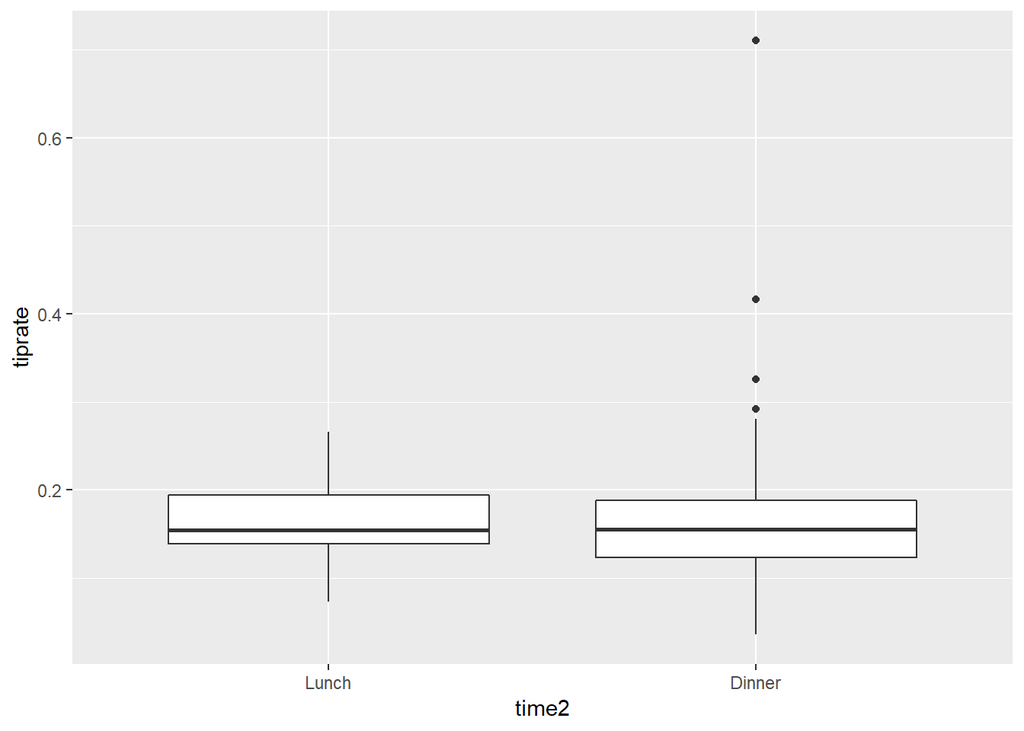

```r
tips$time2 <- factor(tips$time, c("Lunch", "Dinner"))
ggplot(tips, aes(x=time2, y=tiprate)) + geom_boxplot()
```

8. How does smoking behavior and gender of the person who pays impact the relationship between tip and total bill? Find a visualization that incorporates all four variables. Interpret the result.

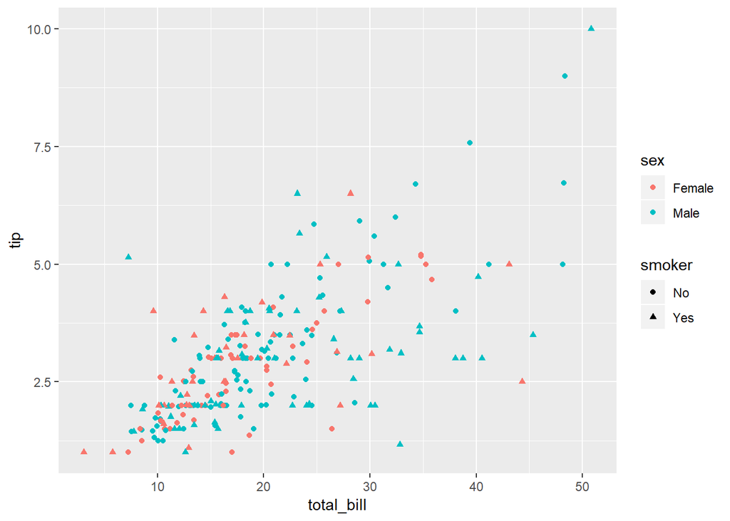

```r
ggplot(tips, aes(x=total_bill, y=tip, shape=smoker, color=sex)) + geom_point()
```

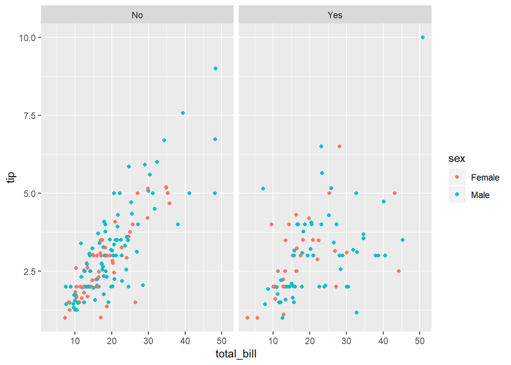

```r
ggplot(tips, aes(x=total_bill, y=tip, color=sex)) + geom_point() + facet_wrap(~smoker)
```

Initially I included the four variables in a scatterplot by letting `smoker` determine the shape and `sex` determine the color of the points. The resulting plot was difficult to understand, so I tried a different approach. In the second plot, I still let `sex` determine color of the points, but I used facetting to show smokers and non-smokers in separate panes.

In general, the correlation between `total_bill` and `tip` was stronger for non-smokers than it was for smokers. It appears that non-smoking males tip higher on a given bill than non-smoking females, but smoking females tip higher than smoking males on a given bill. It appears females tip roughly the same regardless of smoking status, but smoking males tip less than non-smoking males.

9. Use ggplot2 to find a graphical summary of the relationship between day of the week and gender of the person paying the bill. What can you say about this relationship?

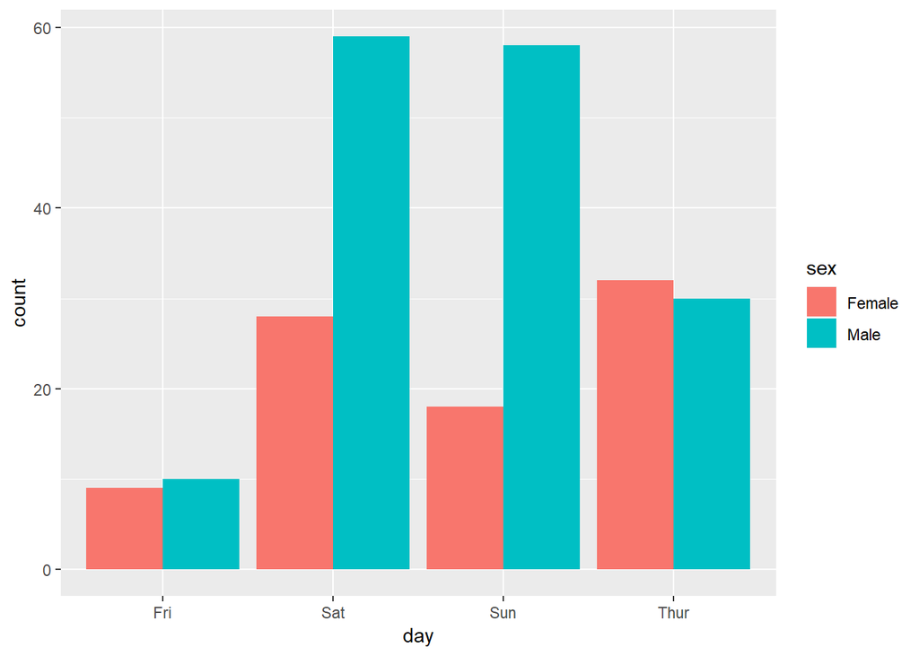

```r
ggplot(tips, aes(x=day, fill=sex)) + geom_bar(position='dodge')
```

On Thursdays and Fridays, the number of males that pay and number of females that pay are almost equal. On Saturday and Sunday, however, the number of males that pay is much higher than the number of females that pay.